# Google Apps 商店的数据分析

## 简介

相信大家对移动应用商店都不陌生吧。Google Play Store（Google Play商店）是谷歌官方的软件应用商店，拥有上架软件数十万款，下载量更是突破了20亿次，为了手机用户提供了极为广泛的应用选择，很受大家的欢迎。

本数据集(googleplaystore.csv)包含了 Google Play 商店中 App 的数据。该数据是Kaggle中 [Google Play Store Apps](https://www.kaggle.com/lava18/google-play-store-apps) 的一部分，其中包含 Google Play 商店中 10k+ 应用软件的信息。

数据中的变量含义解释：

```
App: 应用的名称，字符变量。
Category: 应用所属的分类，字符变量。
Rating: 某应用的用户评分，数值变量。
Reviews: 某应用获得的用户评论数量，数值变量。
Size: 某应用的所占存储空间的大小，字符变量。
Installs: 用户安装和下载某应用的次数，字符变量。
Type: 付费或免费，分类变量。
Price: 价格，字符变量。
Content Rating: 应用商店针对内容给出的年龄评级组 - Children / Mature 21+ / Adult，分类变量。
Genres: 类型/流派，一个应用可以属于多个流派，比如音乐、游戏、家庭等，字符变量。
Last Updated: 应用最新更新的日期，字符变量。
Current Ver: 当前应用的版本，字符变量。
Android Ver: 安装该应用所需要的最低安卓版本，字符变量。
```

## 项目完成指南

本项目中的数据分析流程已经给出，但代码将完全由你自己进行书写，如果你无法完成本项目，说明你目前的能力并不足以完成 数据分析(进阶)纳米学位，建议先进行 数据分析（入门）纳米学位的学习，掌握进阶课程的先修知识。

对于数据分析过程的记录也是数据分析报告的一个重要部分，你可以自己在需要的位置插入Markdown cell，记录你在数据分析中的关键步骤和推理过程。比如：数据有什么样的特点，统计数据的含义是什么，你从可视化中可以得出什么结论，下一步分析是什么，为什么执行这种分析。如果你无法做到这一点，你也无法通过本项目。

> **小贴士**: 像这样的引用部分旨在为学员提供实用指导，帮助学员了解并使用 Jupyter notebook

## 提出问题

在此项目中，你将以一名数据分析师的身份执行数据的探索性分析。你将了解数据分析过程的基本流程。在你分析数据之前，请先思考几个你需要了解的关于 Google 商店中应用的问题，例如，最受欢迎（下载量最高）的 Apps 有什么特征？哪些 App 的评分更高？

**问题**：下载量最高的 Apps 有什么特征？

在提出了问题之后，我们将开始导入数据，并对数据进行探索性分析，来回答上面提出的问题。

> **小贴士**: 双击上框，文本就会发生变化，所有格式都会被清除，以便你编辑该文本块。该文本块是用 [Markdown](http://daringfireball.net/projects/markdown/syntax)编写的，该语言使用纯文本语法，能用页眉、链接、斜体等来规范文本格式。在纳米学位课程中，你也会用到 Markdown。编辑后，可使用 **Shift** + **Enter** 或 **Shift** + **Return** 运行上该框，使其呈现出编辑好的文本格式。

## 数据评估和清理

> **小贴士**: 运行代码框的方法与编辑上方的 Markdown 框的格式类似，你只需点击代码框，按下键盘快捷键 **Shift** + **Enter** 或 **Shift** + **Return** ，或者你也可先选择代码框，然后点击工具栏的 **运行** 按钮来运行代码。运行代码框时，相应单元左侧的信息会出现星号，即 `In [*]:`，若代码执行完毕，星号则会变为某个数字，如 `In [1]`。如果代码运行后有输出结果，输出将会以 `Out [1]:` 的形式出现，其中的数字将与 "In" 中的数字相对应。

```python
# 请先运行此代码块，以确保在可视化中可以显示中文
!rm -rf ~/.cache/matplotlib/fontList.json
!wget http://d.xiazaiziti.com/en_fonts/fonts/s/SimHei.ttf -O /opt/conda/lib/python3.6/site-packages/matplotlib/mpl-data/fonts/ttf/SimHei.ttf
import matplotlib.pyplot as plt

plt.rcParams['font.sans-serif']=['SimHei'] #用来正常显示中文标签
plt.rcParams['axes.unicode_minus']=False #用来正常显示负号
```

[output not shown]

```python
# TO DO: load pacakges
import pandas as pd
import numpy as np
import seaborn as sns
% matplotlib inline
```

```python
# TO DO: load the dataset
df = pd.read_csv("googleplaystore.csv")
df
```

|  | App | Category | Rating | Reviews | Size | Installs | Type | Price | Content Rating | Genres | Last Updated | Current Ver | Android Ver |
| --- | --- | --- | --- | --- | --- | --- | --- | --- | --- | --- | --- | --- | --- |
| 0 | Photo Editor & Candy Camera & Grid & ScrapBook | ART_AND_DESIGN | 4.1 | 159 | 19M | 10,000+ | Free | 0 | Everyone | Art & Design | January 7, 2018 | 1.0.0 | 4.0.3 and up |
| 1 | Coloring book moana | ART_AND_DESIGN | 3.9 | 967 | 14M | 500,000+ | Free | 0 | Everyone | Art & Design;Pretend Play | January 15, 2018 | 2.0.0 | 4.0.3 and up |
| 2 | U Launcher Lite – FREE Live Cool Themes, Hide ... | ART_AND_DESIGN | 4.7 | 87510 | 8.7M | 5,000,000+ | Free | 0 | Everyone | Art & Design | August 1, 2018 | 1.2.4 | 4.0.3 and up |
| 3 | Sketch - Draw & Paint | ART_AND_DESIGN | 4.5 | 215644 | 25M | 50,000,000+ | Free | 0 | Teen | Art & Design | June 8, 2018 | Varies with device | 4.2 and up |
| 4 | Pixel Draw - Number Art Coloring Book | ART_AND_DESIGN | 4.3 | 967 | 2.8M | 100,000+ | Free | 0 | Everyone | Art & Design;Creativity | June 20, 2018 | 1.1 | 4.4 and up |
| 5 | Paper flowers instructions | ART_AND_DESIGN | 4.4 | 167 | 5.6M | 50,000+ | Free | 0 | Everyone | Art & Design | March 26, 2017 | 1.0 | 2.3 and up |
| 6 | Smoke Effect Photo Maker - Smoke Editor | ART_AND_DESIGN | 3.8 | 178 | 19M | 50,000+ | Free | 0 | Everyone | Art & Design | April 26, 2018 | 1.1 | 4.0.3 and up |
| 7 | Infinite Painter | ART_AND_DESIGN | 4.1 | 36815 | 29M | 1,000,000+ | Free | 0 | Everyone | Art & Design | June 14, 2018 | 6.1.61.1 | 4.2 and up |
| 8 | Garden Coloring Book | ART_AND_DESIGN | 4.4 | 13791 | 33M | 1,000,000+ | Free | 0 | Everyone | Art & Design | September 20, 2017 | 2.9.2 | 3.0 and up |
| 9 | Kids Paint Free - Drawing Fun | ART_AND_DESIGN | 4.7 | 121 | 3.1M | 10,000+ | Free | 0 | Everyone | Art & Design;Creativity | July 3, 2018 | 2.8 | 4.0.3 and up |
| 10 | Text on Photo - Fonteee | ART_AND_DESIGN | 4.4 | 13880 | 28M | 1,000,000+ | Free | 0 | Everyone | Art & Design | October 27, 2017 | 1.0.4 | 4.1 and up |
| 11 | Name Art Photo Editor - Focus n Filters | ART_AND_DESIGN | 4.4 | 8788 | 12M | 1,000,000+ | Free | 0 | Everyone | Art & Design | July 31, 2018 | 1.0.15 | 4.0 and up |
| 12 | Tattoo Name On My Photo Editor | ART_AND_DESIGN | 4.2 | 44829 | 20M | 10,000,000+ | Free | 0 | Teen | Art & Design | April 2, 2018 | 3.8 | 4.1 and up |
| 13 | Mandala Coloring Book | ART_AND_DESIGN | 4.6 | 4326 | 21M | 100,000+ | Free | 0 | Everyone | Art & Design | June 26, 2018 | 1.0.4 | 4.4 and up |
| 14 | 3D Color Pixel by Number - Sandbox Art Coloring | ART_AND_DESIGN | 4.4 | 1518 | 37M | 100,000+ | Free | 0 | Everyone | Art & Design | August 3, 2018 | 1.2.3 | 2.3 and up |
| 15 | Learn To Draw Kawaii Characters | ART_AND_DESIGN | 3.2 | 55 | 2.7M | 5,000+ | Free | 0 | Everyone | Art & Design | June 6, 2018 | NaN | 4.2 and up |
| 16 | Photo Designer - Write your name with shapes | ART_AND_DESIGN | 4.7 | 3632 | 5.5M | 500,000+ | Free | 0 | Everyone | Art & Design | July 31, 2018 | 3.1 | 4.1 and up |
| 17 | 350 Diy Room Decor Ideas | ART_AND_DESIGN | 4.5 | 27 | 17M | 10,000+ | Free | 0 | Everyone | Art & Design | November 7, 2017 | 1.0 | 2.3 and up |
| 18 | FlipaClip - Cartoon animation | ART_AND_DESIGN | 4.3 | 194216 | 39M | 5,000,000+ | Free | 0 | Everyone | Art & Design | August 3, 2018 | 2.2.5 | 4.0.3 and up |
| 19 | ibis Paint X | ART_AND_DESIGN | 4.6 | 224399 | 31M | 10,000,000+ | Free | 0 | Everyone | Art & Design | July 30, 2018 | 5.5.4 | 4.1 and up |
| 20 | Logo Maker - Small Business | ART_AND_DESIGN | 4.0 | 450 | 14M | 100,000+ | Free | 0 | Everyone | Art & Design | April 20, 2018 | 4.0 | 4.1 and up |
| 21 | Boys Photo Editor - Six Pack & Men's Suit | ART_AND_DESIGN | 4.1 | 654 | 12M | 100,000+ | Free | 0 | Everyone | Art & Design | March 20, 2018 | 1.1 | 4.0.3 and up |
| 22 | Superheroes Wallpapers \| 4K Backgrounds | ART_AND_DESIGN | 4.7 | 7699 | 4.2M | 500,000+ | Free | 0 | Everyone 10+ | Art & Design | July 12, 2018 | 2.2.6.2 | 4.0.3 and up |
| 23 | Mcqueen Coloring pages | ART_AND_DESIGN | NaN | 61 | 7.0M | 100,000+ | Free | 0 | Everyone | Art & Design;Action & Adventure | March 7, 2018 | 1.0.0 | 4.1 and up |
| 24 | HD Mickey Minnie Wallpapers | ART_AND_DESIGN | 4.7 | 118 | 23M | 50,000+ | Free | 0 | Everyone | Art & Design | July 7, 2018 | 1.1.3 | 4.1 and up |
| 25 | Harley Quinn wallpapers HD | ART_AND_DESIGN | 4.8 | 192 | 6.0M | 10,000+ | Free | 0 | Everyone | Art & Design | April 25, 2018 | 1.5 | 3.0 and up |
| 26 | Colorfit - Drawing & Coloring | ART_AND_DESIGN | 4.7 | 20260 | 25M | 500,000+ | Free | 0 | Everyone | Art & Design;Creativity | October 11, 2017 | 1.0.8 | 4.0.3 and up |
| 27 | Animated Photo Editor | ART_AND_DESIGN | 4.1 | 203 | 6.1M | 100,000+ | Free | 0 | Everyone | Art & Design | March 21, 2018 | 1.03 | 4.0.3 and up |
| 28 | Pencil Sketch Drawing | ART_AND_DESIGN | 3.9 | 136 | 4.6M | 10,000+ | Free | 0 | Everyone | Art & Design | July 12, 2018 | 6.0 | 2.3 and up |
| 29 | Easy Realistic Drawing Tutorial | ART_AND_DESIGN | 4.1 | 223 | 4.2M | 100,000+ | Free | 0 | Everyone | Art & Design | August 22, 2017 | 1.0 | 2.3 and up |
| ... | ... | ... | ... | ... | ... | ... | ... | ... | ... | ... | ... | ... | ... |
| 10811 | FR Plus 1.6 | AUTO_AND_VEHICLES | NaN | 4 | 3.9M | 100+ | Free | 0 | Everyone | Auto & Vehicles | July 24, 2018 | 1.3.6 | 4.4W and up |
| 10812 | Fr Agnel Pune | FAMILY | 4.1 | 80 | 13M | 1,000+ | Free | 0 | Everyone | Education | June 13, 2018 | 2.0.20 | 4.0.3 and up |
| 10813 | DICT.fr Mobile | BUSINESS | NaN | 20 | 2.7M | 10,000+ | Free | 0 | Everyone | Business | July 17, 2018 | 2.1.10 | 4.1 and up |
| 10814 | FR: My Secret Pets! | FAMILY | 4.0 | 785 | 31M | 50,000+ | Free | 0 | Teen | Entertainment | June 3, 2015 | 1.3.1 | 3.0 and up |
| 10815 | Golden Dictionary (FR-AR) | BOOKS_AND_REFERENCE | 4.2 | 5775 | 4.9M | 500,000+ | Free | 0 | Everyone | Books & Reference | July 19, 2018 | 7.0.4.6 | 4.2 and up |
| 10816 | FieldBi FR Offline | BUSINESS | NaN | 2 | 6.8M | 100+ | Free | 0 | Everyone | Business | August 6, 2018 | 2.1.8 | 4.1 and up |
| 10817 | HTC Sense Input - FR | TOOLS | 4.0 | 885 | 8.0M | 100,000+ | Free | 0 | Everyone | Tools | October 30, 2015 | 1.0.612928 | 5.0 and up |
| 10818 | Gold Quote - Gold.fr | FINANCE | NaN | 96 | 1.5M | 10,000+ | Free | 0 | Everyone | Finance | May 19, 2016 | 2.3 | 2.2 and up |
| 10819 | Fanfic-FR | BOOKS_AND_REFERENCE | 3.3 | 52 | 3.6M | 5,000+ | Free | 0 | Teen | Books & Reference | August 5, 2017 | 0.3.4 | 4.1 and up |
| 10820 | Fr. Daoud Lamei | FAMILY | 5.0 | 22 | 8.6M | 1,000+ | Free | 0 | Teen | Education | June 27, 2018 | 3.8.0 | 4.1 and up |
| 10821 | Poop FR | FAMILY | NaN | 6 | 2.5M | 50+ | Free | 0 | Everyone | Entertainment | May 29, 2018 | 1.0 | 4.0.3 and up |
| 10822 | PLMGSS FR | PRODUCTIVITY | NaN | 0 | 3.1M | 10+ | Free | 0 | Everyone | Productivity | December 1, 2017 | 1 | 4.4 and up |
| 10823 | List iptv FR | VIDEO_PLAYERS | NaN | 1 | 2.9M | 100+ | Free | 0 | Everyone | Video Players & Editors | April 22, 2018 | 1.0 | 4.0.3 and up |
| 10824 | Cardio-FR | MEDICAL | NaN | 67 | 82M | 10,000+ | Free | 0 | Everyone | Medical | July 31, 2018 | 2.2.2 | 4.4 and up |
| 10825 | Naruto & Boruto FR | SOCIAL | NaN | 7 | 7.7M | 100+ | Free | 0 | Teen | Social | February 2, 2018 | 1.0 | 4.0 and up |
| 10826 | Frim: get new friends on local chat rooms | SOCIAL | 4.0 | 88486 | Varies with device | 5,000,000+ | Free | 0 | Mature 17+ | Social | March 23, 2018 | Varies with device | Varies with device |
| 10827 | Fr Agnel Ambarnath | FAMILY | 4.2 | 117 | 13M | 5,000+ | Free | 0 | Everyone | Education | June 13, 2018 | 2.0.20 | 4.0.3 and up |
| 10828 | Manga-FR - Anime Vostfr | COMICS | 3.4 | 291 | 13M | 10,000+ | Free | 0 | Everyone | Comics | May 15, 2017 | 2.0.1 | 4.0 and up |
| 10829 | Bulgarian French Dictionary Fr | BOOKS_AND_REFERENCE | 4.6 | 603 | 7.4M | 10,000+ | Free | 0 | Everyone | Books & Reference | June 19, 2016 | 2.96 | 4.1 and up |
| 10830 | News Minecraft.fr | NEWS_AND_MAGAZINES | 3.8 | 881 | 2.3M | 100,000+ | Free | 0 | Everyone | News & Magazines | January 20, 2014 | 1.5 | 1.6 and up |
| 10831 | payermonstationnement.fr | MAPS_AND_NAVIGATION | NaN | 38 | 9.8M | 5,000+ | Free | 0 | Everyone | Maps & Navigation | June 13, 2018 | 2.0.148.0 | 4.0 and up |
| 10832 | FR Tides | WEATHER | 3.8 | 1195 | 582k | 100,000+ | Free | 0 | Everyone | Weather | February 16, 2014 | 6.0 | 2.1 and up |
| 10833 | Chemin (fr) | BOOKS_AND_REFERENCE | 4.8 | 44 | 619k | 1,000+ | Free | 0 | Everyone | Books & Reference | March 23, 2014 | 0.8 | 2.2 and up |
| 10834 | FR Calculator | FAMILY | 4.0 | 7 | 2.6M | 500+ | Free | 0 | Everyone | Education | June 18, 2017 | 1.0.0 | 4.1 and up |
| 10835 | FR Forms | BUSINESS | NaN | 0 | 9.6M | 10+ | Free | 0 | Everyone | Business | September 29, 2016 | 1.1.5 | 4.0 and up |
| 10836 | Sya9a Maroc - FR | FAMILY | 4.5 | 38 | 53M | 5,000+ | Free | 0 | Everyone | Education | July 25, 2017 | 1.48 | 4.1 and up |
| 10837 | Fr. Mike Schmitz Audio Teachings | FAMILY | 5.0 | 4 | 3.6M | 100+ | Free | 0 | Everyone | Education | July 6, 2018 | 1.0 | 4.1 and up |
| 10838 | Parkinson Exercices FR | MEDICAL | NaN | 3 | 9.5M | 1,000+ | Free | 0 | Everyone | Medical | January 20, 2017 | 1.0 | 2.2 and up |
| 10839 | The SCP Foundation DB fr nn5n | BOOKS_AND_REFERENCE | 4.5 | 114 | Varies with device | 1,000+ | Free | 0 | Mature 17+ | Books & Reference | January 19, 2015 | Varies with device | Varies with device |
| 10840 | iHoroscope - 2018 Daily Horoscope & Astrology | LIFESTYLE | 4.5 | 398307 | 19M | 10,000,000+ | Free | 0 | Everyone | Lifestyle | July 25, 2018 | Varies with device | Varies with device |

10841 rows × 13 columns

```python
# TO DO: check the dataset general info
df.info()
```

```
<class 'pandas.core.frame.DataFrame'>
RangeIndex: 10841 entries, 0 to 10840
Data columns (total 13 columns):
App               10841 non-null object
Category          10841 non-null object
Rating            9367 non-null float64
Reviews           10841 non-null object
Size              10841 non-null object
Installs          10841 non-null object
Type              10840 non-null object
Price             10841 non-null object
Content Rating    10840 non-null object
Genres            10841 non-null object
Last Updated      10841 non-null object
Current Ver       10833 non-null object
Android Ver       10838 non-null object
dtypes: float64(1), object(12)
memory usage: 1.1+ MB
```

```python
# TO DO: clean the data (optional: only there are problems)

print(df['App'].unique().size)
```

```
9660
```

```python
print(df['Category'].value_counts(dropna=False))
print(df[df['Category']=='1.9'])
```

```
FAMILY                 1972
GAME                   1144
TOOLS                   843
MEDICAL                 463
BUSINESS                460
PRODUCTIVITY            424
PERSONALIZATION         392
COMMUNICATION           387
SPORTS                  384
LIFESTYLE               382
FINANCE                 366
HEALTH_AND_FITNESS      341
PHOTOGRAPHY             335
SOCIAL                  295
NEWS_AND_MAGAZINES      283
SHOPPING                260
TRAVEL_AND_LOCAL        258
DATING                  234
BOOKS_AND_REFERENCE     231
VIDEO_PLAYERS           175
EDUCATION               156
ENTERTAINMENT           149
MAPS_AND_NAVIGATION     137
FOOD_AND_DRINK          127
HOUSE_AND_HOME           88
LIBRARIES_AND_DEMO       85
AUTO_AND_VEHICLES        85
WEATHER                  82
ART_AND_DESIGN           65
EVENTS                   64
PARENTING                60
COMICS                   60
BEAUTY                   53
1.9                       1
Name: Category, dtype: int64
                                           App Category  Rating Reviews  \
10472  Life Made WI-Fi Touchscreen Photo Frame      1.9    19.0    3.0M

         Size Installs Type     Price Content Rating             Genres  \
10472  1,000+     Free    0  Everyone            NaN  February 11, 2018

      Last Updated Current Ver Android Ver
10472       1.0.19  4.0 and up         NaN
```

```python
# drop error
df.drop(index=10472,inplace=True)
```

```python
print(df['Rating'].value_counts(dropna=False))
```

```
NaN    1474
4.4    1109
4.3    1076
4.5    1038
4.2     952
4.6     823
4.1     708
4.0     568
4.7     499
3.9     386
3.8     303
5.0     274
3.7     239
4.8     234
3.6     174
3.5     163
3.4     128
3.3     102
4.9      87
3.0      83
3.1      69
3.2      64
2.9      45
2.8      42
2.7      25
2.6      25
2.5      21
2.3      20
2.4      19
1.0      16
2.2      14
1.9      13
2.0      12
1.7       8
1.8       8
2.1       8
1.6       4
1.5       3
1.4       3
1.2       1
Name: Rating, dtype: int64
```

```python
df['Rating'].fillna(value=df['Rating'].mean(),inplace=True)
```

```python
print(df['Rating'].value_counts(dropna=False))
print(df['Reviews'].str.isnumeric().sum())
```

```
4.191757    1474
4.400000    1109
4.300000    1076
4.500000    1038
4.200000     952
4.600000     823
4.100000     708
4.000000     568
4.700000     499
3.900000     386
3.800000     303
5.000000     274
3.700000     239
4.800000     234
3.600000     174
3.500000     163
3.400000     128
3.300000     102
4.900000      87
3.000000      83
3.100000      69
3.200000      64
2.900000      45
2.800000      42
2.700000      25
2.600000      25
2.500000      21
2.300000      20
2.400000      19
1.000000      16
2.200000      14
1.900000      13
2.000000      12
1.800000       8
1.700000       8
2.100000       8
1.600000       4
1.500000       3
1.400000       3
1.200000       1
Name: Rating, dtype: int64
10840
```

```python
df['Reviews'] = df['Reviews'].astype('i8')
df.describe()
```

|  | Rating | Reviews |
| --- | --- | --- |
| count | 10840.000000 | 1.084000e+04 |
| mean | 4.191757 | 4.441529e+05 |
| std | 0.478907 | 2.927761e+06 |
| min | 1.000000 | 0.000000e+00 |
| 25% | 4.100000 | 3.800000e+01 |
| 50% | 4.200000 | 2.094000e+03 |
| 75% | 4.500000 | 5.477550e+04 |
| max | 5.000000 | 7.815831e+07 |

```python
df['Size'].value_counts()
```

```
Varies with device    1695
11M                    198
12M                    196
14M                    194
13M                    191
                      ...
853k                     1
55k                      1
259k                     1
314k                     1
93k                      1
Name: Size, Length: 461, dtype: int64
```

```python
df['Size']=df['Size'].str.replace('M','e+6')
df['Size']=df['Size'].str.replace('k','e+3')
df['Size']=df['Size'].str.replace('Varies with device', '0')
df['Size']=df['Size'].astype('f8')
df['Size'].replace(0, df['Size'].mean(),inplace=True)
df['Size']
```

```
0        1.900000e+07
1        1.400000e+07
2        8.700000e+06
3        2.500000e+07
4        2.800000e+06
             ...
10836    5.300000e+07
10837    3.600000e+06
10838    9.500000e+06
10839    1.815209e+07
10840    1.900000e+07
Name: Size, Length: 10840, dtype: float64
```

```python
df.describe()
```

|  | Rating | Reviews | Size |
| --- | --- | --- | --- |
| count | 10840.000000 | 1.084000e+04 | 1.084000e+04 |
| mean | 4.191757 | 4.441529e+05 | 2.099045e+07 |
| std | 0.478907 | 2.927761e+06 | 2.078345e+07 |
| min | 1.000000 | 0.000000e+00 | 8.500000e+03 |
| 25% | 4.100000 | 3.800000e+01 | 5.900000e+06 |
| 50% | 4.200000 | 2.094000e+03 | 1.800000e+07 |
| 75% | 4.500000 | 5.477550e+04 | 2.600000e+07 |
| max | 5.000000 | 7.815831e+07 | 1.000000e+08 |

```python
df['Installs'].value_counts()
```

```
1,000,000+        1579
10,000,000+       1252
100,000+          1169
10,000+           1054
1,000+             907
5,000,000+         752
100+               719
500,000+           539
50,000+            479
5,000+             477
100,000,000+       409
10+                386
500+               330
50,000,000+        289
50+                205
5+                  82
500,000,000+        72
1+                  67
1,000,000,000+      58
0+                  14
0                    1
Name: Installs, dtype: int64
```

```python
df['Installs']=df['Installs'].str.replace('+', '')
df['Installs']=df['Installs'].str.replace(',', '')
df['Installs']=df['Installs'].astype('int')
print(df.describe())
```

```
             Rating       Reviews          Size      Installs
count  10840.000000  1.084000e+04  1.084000e+04  1.084000e+04
mean       4.191757  4.441529e+05  2.099045e+07  1.546434e+07
std        0.478907  2.927761e+06  2.078345e+07  8.502936e+07
min        1.000000  0.000000e+00  8.500000e+03  0.000000e+00
25%        4.100000  3.800000e+01  5.900000e+06  1.000000e+03
50%        4.200000  2.094000e+03  1.800000e+07  1.000000e+05
75%        4.500000  5.477550e+04  2.600000e+07  5.000000e+06
max        5.000000  7.815831e+07  1.000000e+08  1.000000e+09
```

```python
print(df['Type'].value_counts(dropna=False))
print(df[df['Type'].isnull()])
```

```
Free    10039
Paid      800
NaN         1
Name: Type, dtype: int64
                            App Category    Rating  Reviews          Size  \
9148  Command & Conquer: Rivals   FAMILY  4.191757        0  1.815209e+07

      Installs Type Price Content Rating    Genres   Last Updated  \
9148         0  NaN     0   Everyone 10+  Strategy  June 28, 2018

             Current Ver         Android Ver
9148  Varies with device  Varies with device
```

```python
df.drop(index=9148, inplace=True)
```

```python
df.drop_duplicates('App', inplace=True)
```

```python
df.describe()
```

|  | Rating | Reviews | Size | Installs |
| --- | --- | --- | --- | --- |
| count | 9658.000000 | 9.658000e+03 | 9.658000e+03 | 9.658000e+03 |
| mean | 4.176046 | 2.166150e+05 | 2.011053e+07 | 7.778312e+06 |
| std | 0.494383 | 1.831413e+06 | 2.040865e+07 | 5.376100e+07 |
| min | 1.000000 | 0.000000e+00 | 8.500000e+03 | 0.000000e+00 |
| 25% | 4.000000 | 2.500000e+01 | 5.300000e+06 | 1.000000e+03 |
| 50% | 4.200000 | 9.670000e+02 | 1.600000e+07 | 1.000000e+05 |
| 75% | 4.500000 | 2.940800e+04 | 2.500000e+07 | 1.000000e+06 |
| max | 5.000000 | 7.815831e+07 | 1.000000e+08 | 1.000000e+09 |

## 数据探索分析

```python
# In exploratory data analysis, please make sure of using statistics and visualizations
df.Category.unique().size
```

```
33
```

```python
Category_App = df.groupby('Category').count().sort_values('App', ascending = False)
Category_App
```

| Category | App | Rating | Reviews | Size | Installs | Type | Price | Content Rating | Genres | Last Updated | Current Ver | Android Ver |
| --- | --- | --- | --- | --- | --- | --- | --- | --- | --- | --- | --- | --- |
| FAMILY | 1831 | 1831 | 1831 | 1831 | 1831 | 1831 | 1831 | 1831 | 1831 | 1831 | 1828 | 1831 |
| GAME | 959 | 959 | 959 | 959 | 959 | 959 | 959 | 959 | 959 | 959 | 959 | 959 |
| TOOLS | 827 | 827 | 827 | 827 | 827 | 827 | 827 | 827 | 827 | 827 | 825 | 827 |
| BUSINESS | 420 | 420 | 420 | 420 | 420 | 420 | 420 | 420 | 420 | 420 | 420 | 420 |
| MEDICAL | 395 | 395 | 395 | 395 | 395 | 395 | 395 | 395 | 395 | 395 | 395 | 395 |
| PERSONALIZATION | 376 | 376 | 376 | 376 | 376 | 376 | 376 | 376 | 376 | 376 | 376 | 374 |
| PRODUCTIVITY | 374 | 374 | 374 | 374 | 374 | 374 | 374 | 374 | 374 | 374 | 374 | 374 |
| LIFESTYLE | 369 | 369 | 369 | 369 | 369 | 369 | 369 | 369 | 369 | 369 | 369 | 369 |
| FINANCE | 345 | 345 | 345 | 345 | 345 | 345 | 345 | 345 | 345 | 345 | 345 | 345 |
| SPORTS | 325 | 325 | 325 | 325 | 325 | 325 | 325 | 325 | 325 | 325 | 325 | 325 |
| COMMUNICATION | 315 | 315 | 315 | 315 | 315 | 315 | 315 | 315 | 315 | 315 | 315 | 315 |
| HEALTH_AND_FITNESS | 288 | 288 | 288 | 288 | 288 | 288 | 288 | 288 | 288 | 288 | 288 | 288 |
| PHOTOGRAPHY | 281 | 281 | 281 | 281 | 281 | 281 | 281 | 281 | 281 | 281 | 281 | 281 |
| NEWS_AND_MAGAZINES | 254 | 254 | 254 | 254 | 254 | 254 | 254 | 254 | 254 | 254 | 254 | 254 |
| SOCIAL | 239 | 239 | 239 | 239 | 239 | 239 | 239 | 239 | 239 | 239 | 239 | 239 |
| BOOKS_AND_REFERENCE | 222 | 222 | 222 | 222 | 222 | 222 | 222 | 222 | 222 | 222 | 221 | 222 |
| TRAVEL_AND_LOCAL | 219 | 219 | 219 | 219 | 219 | 219 | 219 | 219 | 219 | 219 | 219 | 219 |
| SHOPPING | 202 | 202 | 202 | 202 | 202 | 202 | 202 | 202 | 202 | 202 | 202 | 202 |
| DATING | 171 | 171 | 171 | 171 | 171 | 171 | 171 | 171 | 171 | 171 | 171 | 171 |
| VIDEO_PLAYERS | 163 | 163 | 163 | 163 | 163 | 163 | 163 | 163 | 163 | 163 | 163 | 163 |
| MAPS_AND_NAVIGATION | 131 | 131 | 131 | 131 | 131 | 131 | 131 | 131 | 131 | 131 | 131 | 131 |
| EDUCATION | 119 | 119 | 119 | 119 | 119 | 119 | 119 | 119 | 119 | 119 | 119 | 119 |
| FOOD_AND_DRINK | 112 | 112 | 112 | 112 | 112 | 112 | 112 | 112 | 112 | 112 | 112 | 112 |
| ENTERTAINMENT | 102 | 102 | 102 | 102 | 102 | 102 | 102 | 102 | 102 | 102 | 102 | 102 |
| AUTO_AND_VEHICLES | 85 | 85 | 85 | 85 | 85 | 85 | 85 | 85 | 85 | 85 | 85 | 85 |
| LIBRARIES_AND_DEMO | 84 | 84 | 84 | 84 | 84 | 84 | 84 | 84 | 84 | 84 | 83 | 84 |
| WEATHER | 79 | 79 | 79 | 79 | 79 | 79 | 79 | 79 | 79 | 79 | 79 | 79 |
| HOUSE_AND_HOME | 74 | 74 | 74 | 74 | 74 | 74 | 74 | 74 | 74 | 74 | 74 | 74 |
| EVENTS | 64 | 64 | 64 | 64 | 64 | 64 | 64 | 64 | 64 | 64 | 64 | 64 |
| ART_AND_DESIGN | 64 | 64 | 64 | 64 | 64 | 64 | 64 | 64 | 64 | 64 | 63 | 64 |
| PARENTING | 60 | 60 | 60 | 60 | 60 | 60 | 60 | 60 | 60 | 60 | 60 | 60 |
| COMICS | 56 | 56 | 56 | 56 | 56 | 56 | 56 | 56 | 56 | 56 | 56 | 56 |
| BEAUTY | 53 | 53 | 53 | 53 | 53 | 53 | 53 | 53 | 53 | 53 | 53 | 53 |

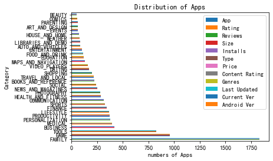

```python
plt.figure(figsize=(30,10),dpi=40)
Category_App.plot(kind='barh')
plt.xlabel('numbers of Apps')
plt.title('Distribution of Apps')
plt.show()
```

```python
top_10 = df.groupby('Category').count()['App'].sort_values(ascending=False)[:10]
print(top_10)
```

```
Category
FAMILY             1831
GAME                959
TOOLS               827
BUSINESS            420
MEDICAL             395
PERSONALIZATION     376
PRODUCTIVITY        374
LIFESTYLE           369
FINANCE             345
SPORTS              325
Name: App, dtype: int64
```

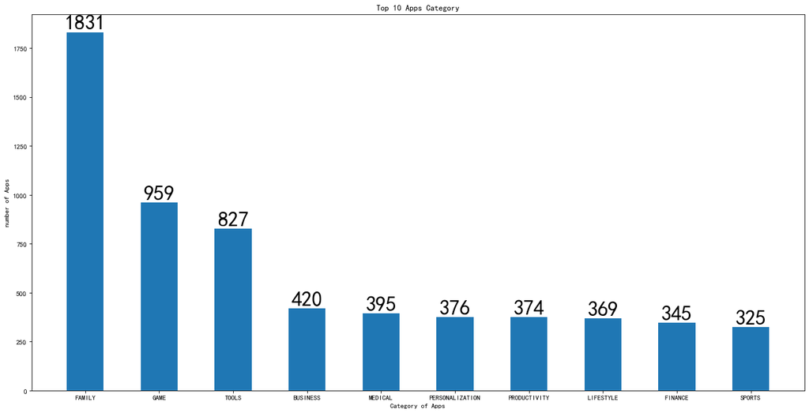

```python
plt.figure(figsize=(20,10),dpi=80)
x = top_10.index
y = top_10.values

for a, b in zip(x, y):
    plt.text(a,b,b, ha='center',va='bottom', fontsize=30)
plt.bar(x, y, width= 0.5)
plt.xlabel('Category of Apps')
plt.ylabel('number of Apps')
plt.title('Top 10 Apps Category')
plt.show()
```

```python
Ca_Rating_mean = df.groupby('Category').mean()['Rating'].sort_values(ascending=False)
Ca_Rating_mean
```

```
Category
EVENTS                 4.363178
EDUCATION              4.362956
ART_AND_DESIGN         4.349614
BOOKS_AND_REFERENCE    4.308393
PERSONALIZATION        4.303077
PARENTING              4.281960
BEAUTY                 4.260553
GAME                   4.244643
SOCIAL                 4.238926
WEATHER                4.238510
HEALTH_AND_FITNESS     4.235199
SHOPPING               4.225835
SPORTS                 4.211275
AUTO_AND_VEHICLES      4.190601
PRODUCTIVITY           4.185022
COMICS                 4.181848
LIBRARIES_AND_DEMO     4.181371
FAMILY                 4.181137
FOOD_AND_DRINK         4.175461
MEDICAL                4.173252
PHOTOGRAPHY            4.159614
HOUSE_AND_HOME         4.156771
NEWS_AND_MAGAZINES     4.135385
ENTERTAINMENT          4.135294
COMMUNICATION          4.134647
BUSINESS               4.133347
FINANCE                4.125060
LIFESTYLE              4.111489
TRAVEL_AND_LOCAL       4.087380
TOOLS                  4.059615
VIDEO_PLAYERS          4.058137
MAPS_AND_NAVIGATION    4.051854
DATING                 4.018100
Name: Rating, dtype: float64
```

```python
df.groupby('Type')['App'].count()
```

```
Type
Free    8902
Paid     756
Name: App, dtype: int64
```

```python
df.groupby('Type').sum()['Installs'].sort_values(ascending=False)
```

```
Type
Free    7.506557e+10
Paid    5.736488e+07
Name: Installs, dtype: float64
```

```python
Ty_Cat = df.groupby(['Type', 'Category']).mean()
(Ty_Cat['Reviews']/Ty_Cat['Installs']).sort_values(ascending=False)
```

```
Type  Category
Paid  VIDEO_PLAYERS          0.188268
      FAMILY                 0.175913
      WEATHER                0.168031
      PARENTING              0.166986
      DATING                 0.141674
                               ...
Free  BOOKS_AND_REFERENCE    0.010036
      NEWS_AND_MAGAZINES     0.009763
      PRODUCTIVITY           0.009569
      TRAVEL_AND_LOCAL       0.009259
Paid  EVENTS                 0.000000
Length: 63, dtype: float64
```

```python
df.corr()
```

|  | Rating | Reviews | Size | Installs |
| --- | --- | --- | --- | --- |
| Rating | 1.000000 | 0.054337 | 0.052751 | 0.039245 |
| Reviews | 0.054337 | 1.000000 | 0.080578 | 0.625164 |
| Size | 0.052751 | 0.080578 | 1.000000 | 0.050675 |
| Installs | 0.039245 | 0.625164 | 0.050675 | 1.000000 |

在数据的探索性分析中，请确保你对数据分析中的关键步骤和推理过程进行了记录。你可以自己插入code cell和markdown cell来组织你的报告。

## 反思

**问题**：在你的分析和总结过程中是否存在逻辑严谨。是否有改进的空间? 你可以从下面的一些角度进行思考：

1. 数据集是否完整，包含所有想要分析的数据？
2. 在对数据进行处理的时候，你的操作（例如删除/填充缺失值）是否可能影响结论？
3. 是否还有其他变量（本数据中没有）能够对你的分析有帮助？
4. 在得出结论时，你是否混淆了相关性和因果性？

恭喜你完成了此项目！这只是数据分析过程的一个样本：从生成问题、整理数据、探索数据到得出结论。在数据分析(进阶)纳米学位中，你将会学到更多高级的数据分析方法和技术，如果你感兴趣的话，我们鼓励你继续学习后续的课程，掌握更多的数据分析的高级技能！

> 若想与他人分享我们的分析结果，除了向他们提供 jupyter Notebook (.ipynb) 文件的副本外，我们还可以将 Notebook 输出导出为一种甚至那些未安装 Python 的人都能打开的形式。从左上方的“文件”菜单，前往“下载为”子菜单。然后你可以选择一个可以更普遍查看的格式，例如 HTML (.html) 。你可能需要额外软件包或软件来执行这些导出。